# EDA demo

Taavi Päll

27 9 2017

```r
library(tidyverse)
library(stringr)
```

## Download dataset

```r
if(!file.exists("data/cacancer_newcases_PK10.json")){
  url <- "https://raw.githubusercontent.com/rstats-tartu/datasets/master/cancer_newcases_PK10.json"
  dir.create("data")
  download.file(url, "data/incidence.json")
}
```

Install boulder library to import json.

```r
# install.packages("devtools")
# devtools::install_github("tpall/boulder")
```

## Import dataset

```r
library(boulder)
incidence <- json_to_df("data/incidence.json")
```

```
## Data source is Estonian Cancer Registry.
```

Load tidyverse libraries:

```r
library(tidyverse)
library(stringi)
library(stringr) # this is what you are going to need most in future
```

For better overview let’s filter out “Specified site” values that are longer than 30 characters.

```r
filter(incidence, str_length(`Specified site`) < 30)
```

```
## # A tibble: 1,110 x 24
##      Year           `Specified site`    Sex `0-4` `5-9` `10-14` `15-19`
##    <fctr>                     <fctr> <fctr> <int> <int>   <int>   <int>
##  1   2000                ..Lip (C00)    Men     0     0       0       0
##  2   2000                ..Lip (C00)  Women     0     0       0       0
##  3   2000          ..Tongue (C01-02)    Men     0     0       0       0
##  4   2000          ..Tongue (C01-02)  Women     0     0       0       0
##  5   2000        ..Nasopharynx (C11)    Men     0     0       0       0
##  6   2000        ..Nasopharynx (C11)  Women     1     0       0       0
##  7   2000 Digestive organs (C15-C26)    Men     1     0       0       0
##  8   2000 Digestive organs (C15-C26)  Women     0     0       0       0
##  9   2000         ..Oesophagus (C15)    Men     0     0       0       0
## 10   2000         ..Oesophagus (C15)  Women     0     0       0       0
## # ... with 1,100 more rows, and 17 more variables: `20-24` <int>,
## #   `25-29` <int>, `30-34` <int>, `35-39` <int>, `40-44` <int>,
## #   `45-49` <int>, `50-54` <int>, `55-59` <int>, `60-64` <int>,
## #   `65-69` <int>, `70-74` <int>, `75-79` <int>, `80-84` <int>, `85 and
## #   older` <int>, label <chr>, source <chr>, updated <chr>
```

Convert Year to numeric

```r
incidence <- incidence %>% mutate_at("Year", parse_number)
```

Specified site and sex to characters

```r
?mutate_at
incidence <- incidence %>% mutate_at(c("Specified site","Sex"), parse_character)
incidence
```

```
## # A tibble: 2,190 x 24
##     Year                                                  `Specified site`
##    <dbl>                                                             <chr>
##  1  2000                                 All malignant neoplasms (C00-C97)
##  2  2000                                 All malignant neoplasms (C00-C97)
##  3  2000 All malignant neoplasms except skin (other) (C00-C97, except C44)
##  4  2000 All malignant neoplasms except skin (other) (C00-C97, except C44)
##  5  2000                            Lip, oral cavity and pharynx (C00-C14)
##  6  2000                            Lip, oral cavity and pharynx (C00-C14)
##  7  2000                                                       ..Lip (C00)
##  8  2000                                                       ..Lip (C00)
##  9  2000                                                 ..Tongue (C01-02)
## 10  2000                                                 ..Tongue (C01-02)
## # ... with 2,180 more rows, and 22 more variables: Sex <chr>, `0-4` <int>,
## #   `5-9` <int>, `10-14` <int>, `15-19` <int>, `20-24` <int>,
## #   `25-29` <int>, `30-34` <int>, `35-39` <int>, `40-44` <int>,
## #   `45-49` <int>, `50-54` <int>, `55-59` <int>, `60-64` <int>,
## #   `65-69` <int>, `70-74` <int>, `75-79` <int>, `80-84` <int>, `85 and
## #   older` <int>, label <chr>, source <chr>, updated <chr>
```

We move variables “label”, “source”, and “updated” to separate object for later use in plot annotation.

```r
label <- unique(incidence$label)
data_source <- unique(incidence$source)
updated <- unique(incidence$updated)
label
```

```
## [1] "New cases of malignant neoplasms"
```

```r
data_source
```

```
## [1] "Estonian Cancer Registry"
```

```r
updated
```

```
## [1] "2015-06-18T08:31:00Z"
```

```r
incidence <- incidence %>%
  mutate(Site = stri_trim_left(`Specified site`, "[[:alpha:]]")) %>%
  select(Year, Site, Sex, everything(), -`Specified site`, -label, -source, -updated)
incidence
```

```
## # A tibble: 2,190 x 21
##     Year                                                              Site
##    <dbl>                                                             <chr>
##  1  2000                                 All malignant neoplasms (C00-C97)
##  2  2000                                 All malignant neoplasms (C00-C97)
##  3  2000 All malignant neoplasms except skin (other) (C00-C97, except C44)
##  4  2000 All malignant neoplasms except skin (other) (C00-C97, except C44)
##  5  2000                            Lip, oral cavity and pharynx (C00-C14)
##  6  2000                            Lip, oral cavity and pharynx (C00-C14)
##  7  2000                                                         Lip (C00)
##  8  2000                                                         Lip (C00)
##  9  2000                                                   Tongue (C01-02)
## 10  2000                                                   Tongue (C01-02)
## # ... with 2,180 more rows, and 19 more variables: Sex <chr>, `0-4` <int>,
## #   `5-9` <int>, `10-14` <int>, `15-19` <int>, `20-24` <int>,
## #   `25-29` <int>, `30-34` <int>, `35-39` <int>, `40-44` <int>,
## #   `45-49` <int>, `50-54` <int>, `55-59` <int>, `60-64` <int>,
## #   `65-69` <int>, `70-74` <int>, `75-79` <int>, `80-84` <int>, `85 and
## #   older` <int>
```

It’s not what we want…

```r
gather(incidence)
```

```
## # A tibble: 45,990 x 2
##      key value
##    <chr> <chr>
##  1  Year  2000
##  2  Year  2000
##  3  Year  2000
##  4  Year  2000
##  5  Year  2000
##  6  Year  2000
##  7  Year  2000
##  8  Year  2000
##  9  Year  2000
## 10  Year  2000
## # ... with 45,980 more rows
```

Convert incidence from wide to long:

```r
incidence_long <- gather(incidence,
                         key = age,
                         value = cases,
                         matches("[[:digit:]]"))
# gather(incidence, key = age, value = cases, -Year, -Sex, -Site)
incidence_long
```

```
## # A tibble: 39,420 x 5
##     Year                                                              Site
##    <dbl>                                                             <chr>
##  1  2000                                 All malignant neoplasms (C00-C97)
##  2  2000                                 All malignant neoplasms (C00-C97)
##  3  2000 All malignant neoplasms except skin (other) (C00-C97, except C44)
##  4  2000 All malignant neoplasms except skin (other) (C00-C97, except C44)
##  5  2000                            Lip, oral cavity and pharynx (C00-C14)
##  6  2000                            Lip, oral cavity and pharynx (C00-C14)
##  7  2000                                                         Lip (C00)
##  8  2000                                                         Lip (C00)
##  9  2000                                                   Tongue (C01-02)
## 10  2000                                                   Tongue (C01-02)
## # ... with 39,410 more rows, and 3 more variables: Sex <chr>, age <chr>,
## #   cases <int>
```

Let’s filter out NA-s.

```r
incidence_long <- drop_na(incidence_long)
```

That’s all with data wrangling for now!

## Cancer trend in Estonia

Plot number of all cancer cases (Men + Women) per Year:

```r
total_cases_per_year <- incidence_long %>%
  filter(Site == "All malignant neoplasms (C00-C97)") %>%
  group_by(Year) %>%
  summarise(total_cases = sum(cases))
total_cases_per_year
```

```
## # A tibble: 15 x 2
##     Year total_cases
##    <dbl>       <int>
##  1  2000        6032
##  2  2001        6237
##  3  2002        6119
##  4  2003        6378
##  5  2004        6813
##  6  2005        6525
##  7  2006        7190
##  8  2007        7280
##  9  2008        7330
## 10  2009        7391
## 11  2010        7841
## 12  2011        8204
## 13  2012        8245
## 14  2013        8420
## 15  2014        8558
```

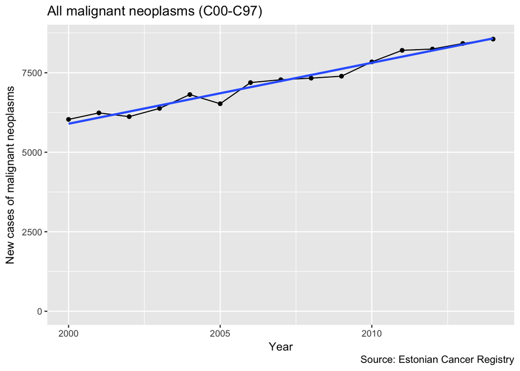

```r
p <- total_cases_per_year %>%
  ggplot(aes(Year, total_cases)) +
  geom_point() +
  geom_line() +
  labs(title = "All malignant neoplasms (C00-C97)",
       caption = paste("Source:", data_source),
       y = label) +
  expand_limits(y = 0) +
  geom_smooth(method = "lm", se = FALSE)
p
```

Ok, trend is increasing, but how much?

```r
cases_range <- range(total_cases_per_year$total_cases)
(1 - cases_range[1] / cases_range[2]) * 100
```

```
## [1] 29.51624
```

Please compare number of cases in male and females:

```r
total_cases_per_year_sex <- incidence_long %>%
  filter(Site == "All malignant neoplasms (C00-C97)") %>%
  group_by(Year, Sex) %>%
  summarise(total_cases = sum(cases))
```

Here we replace data and aes in previous plot called “p”:

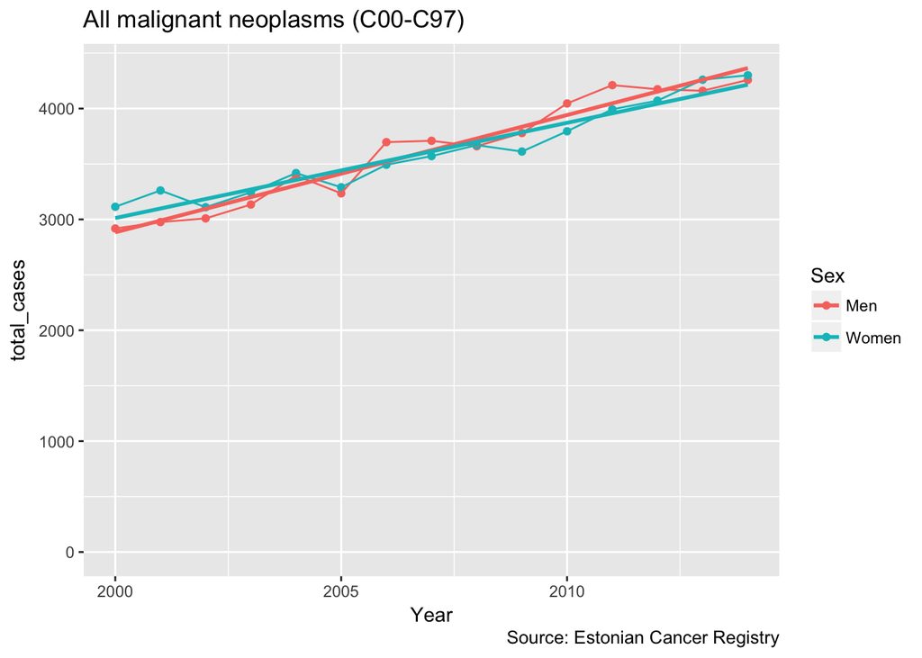

```r
p %+% total_cases_per_year_sex + aes(Year, total_cases, color = Sex)
```

Perhaps we want to completely rewrite our plot and throw out linear model lines and expand limits option:

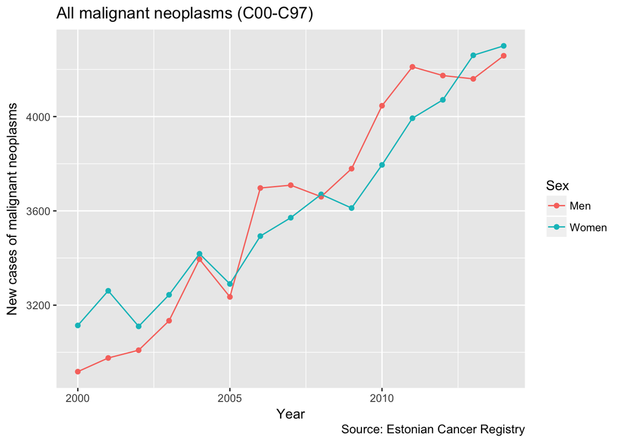

```r
total_cases_per_year_sex %>%
  ggplot(aes(Year, total_cases, color = Sex)) +
  geom_point() +
  geom_line() +
  labs(title = "All malignant neoplasms (C00-C97)",
       caption = paste("Source:", data_source),
       y = label)
```

The **number of cancer cases** is similar in men and women. What about cancer incidence – population size normalised morbidity. Cancer incidence is expressed as number of cases per 100000 inhabitants. To calculate incidence, we need population size data.

Incidence is calculated like this.

```
incidence = (number of cases / mean annual population) * 100000
```

## NIH Cancer Incidence Rates

A cancer incidence rate is the number of new cancers of a specific site/type occurring in a specified population during a year, usually expressed as the number of cancers per 100,000 population at risk. That is,

Incidence rate = (New cancers / Population) × 100,000

The numerator of the incidence rate is the number of new cancers; the denominator is the size of the population. The number of new cancers may include multiple primary cancers occurring in one patient. The primary site reported is the site of origin and not the metastatic site. In general, the incidence rate would not include recurrences. The population used depends on the rate to be calculated. For cancer sites that occur in only one sex, the sex-specific population (e.g., females for cervical cancer) is used.

Let’s get population size data for year, sex and per age:

```r
if(!file.exists("data/mean_annual_population.csv")){
  download.file("https://raw.githubusercontent.com/rstats-tartu/datasets/master/mean_annual_population.csv", "data/mean_annual_population.csv")
}
```

Import population dataset to R:

```r
pop <- read_csv("data/mean_annual_population.csv")
pop
```

```
## # A tibble: 94 x 21
##      Sex  Year   `0` `1-4` `5-9` `10-14` `15-19` `20-24` `25-29` `30-34`
##    <chr> <int> <int> <int> <int>   <int>   <int>   <int>   <int>   <int>
##  1   Men  1970 10315 39493 51950   51417   53084   53787   47058   55210
##  2   Men  1971 11008 40589 51387   52276   53190   56042   45176   56373
##  3   Men  1972 11149 42371 50441   53196   53286   57535   45007   56006
##  4   Men  1973 10889 43778 49961   53545   53861   58084   47523   53213
##  5   Men  1974 10757 44504 50093   53287   54508   57978   51560   49706
##  6   Men  1975 10877 44778 50826   52456   55127   58244   55310   46561
##  7   Men  1976 10929 44601 52426   51348   55631   58850   57584   44378
##  8   Men  1977 11079 44326 54237   50155   55903   59217   58757   44123
##  9   Men  1978 11032 44416 55384   49553   55806   59620   59224   46277
## 10   Men  1979 11028 44626 55816   49927   55368   59309   59246   49727
## # ... with 84 more rows, and 11 more variables: `35-39` <int>,
## #   `40-44` <int>, `45-49` <int>, `50-54` <int>, `55-59` <int>,
## #   `60-64` <int>, `65-69` <int>, `70-74` <int>, `75-79` <int>,
## #   `80-84` <int>, `85 and older` <int>
```

Population data is available from 1970 to 2016.

Summarise age groups 0 and 1-4 into age group 0-4; convert table to long format.

```r
pop_long <- pop %>%
  mutate("0-4" = `0` + `1-4`) %>%
  select(-`0`, -`1-4`) %>%
  gather("age", "ave_pop", matches("[0-9]"))
pop_long
```

```
## # A tibble: 1,692 x 4
##      Sex  Year   age ave_pop
##    <chr> <int> <chr>   <int>
##  1   Men  1970   5-9   51950
##  2   Men  1971   5-9   51387
##  3   Men  1972   5-9   50441
##  4   Men  1973   5-9   49961
##  5   Men  1974   5-9   50093
##  6   Men  1975   5-9   50826
##  7   Men  1976   5-9   52426
##  8   Men  1977   5-9   54237
##  9   Men  1978   5-9   55384
## 10   Men  1979   5-9   55816
## # ... with 1,682 more rows
```

Merge cancer cases with population size data. Note that population values only from years 2000 to 2014 will be merged to incidence_long.

```r
incidence_long <- left_join(incidence_long, pop_long)
```

This is how you calculate incidence: Incidence rate = (New cancers / Population) × 100,000

Cancer incidence is given as the number of new cases per 100’000.

```r
incidence_year_sex <- incidence_long %>%
  group_by(Site, Year, Sex) %>%
  summarise(cases = sum(cases),
            ave_pop = sum(ave_pop)) %>%
  mutate(incidence = (cases / ave_pop) * 100000)
incidence_year_sex
```

```
## # A tibble: 2,190 x 6
## # Groups:   Site, Year [1,095]
##                                     Site  Year   Sex cases ave_pop
##                                    <chr> <dbl> <chr> <int>   <int>
##  1 Acute lymphoblastic leukaemia (C91.0)  2000   Men     5  651075
##  2 Acute lymphoblastic leukaemia (C91.0)  2000 Women     7  745910
##  3 Acute lymphoblastic leukaemia (C91.0)  2001   Men     4  646685
##  4 Acute lymphoblastic leukaemia (C91.0)  2001 Women     8  741430
##  5 Acute lymphoblastic leukaemia (C91.0)  2002   Men    10  642145
##  6 Acute lymphoblastic leukaemia (C91.0)  2002 Women     4  737205
##  7 Acute lymphoblastic leukaemia (C91.0)  2003   Men    10  637720
##  8 Acute lymphoblastic leukaemia (C91.0)  2003 Women    10  733000
##  9 Acute lymphoblastic leukaemia (C91.0)  2004   Men     7  633580
## 10 Acute lymphoblastic leukaemia (C91.0)  2004 Women     6  728970
## # ... with 2,180 more rows, and 1 more variables: incidence <dbl>
```

All cancer cases:

```r
incidence_year_sex %>% filter(Site == "All malignant neoplasms (C00-C97)")
```

```
## # A tibble: 30 x 6
## # Groups:   Site, Year [15]
##                                 Site  Year   Sex cases ave_pop incidence
##                                <chr> <dbl> <chr> <int>   <int>     <dbl>
##  1 All malignant neoplasms (C00-C97)  2000   Men  2918  651075  448.1819
##  2 All malignant neoplasms (C00-C97)  2000 Women  3114  745910  417.4766
##  3 All malignant neoplasms (C00-C97)  2001   Men  2976  646685  460.1931
##  4 All malignant neoplasms (C00-C97)  2001 Women  3261  741430  439.8257
##  5 All malignant neoplasms (C00-C97)  2002   Men  3009  642145  468.5858
##  6 All malignant neoplasms (C00-C97)  2002 Women  3110  737205  421.8637
##  7 All malignant neoplasms (C00-C97)  2003   Men  3134  637720  491.4382
##  8 All malignant neoplasms (C00-C97)  2003 Women  3244  733000  442.5648
##  9 All malignant neoplasms (C00-C97)  2004   Men  3395  633580  535.8439
## 10 All malignant neoplasms (C00-C97)  2004 Women  3418  728970  468.8807
## # ... with 20 more rows
```

Cancer incidence in men versus women:

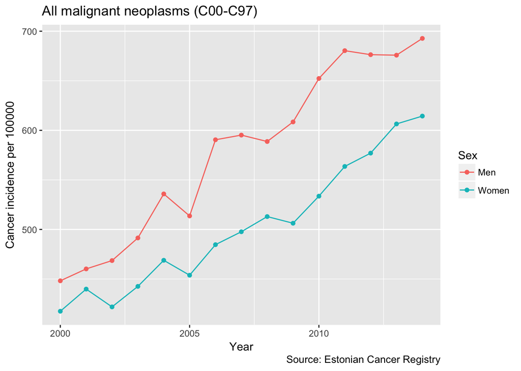

```r
incidence_year_sex %>%
  filter(Site == "All malignant neoplasms (C00-C97)") %>%
  ggplot(aes(Year, incidence, color = Sex)) +
  geom_point() +
  geom_line() +
  labs(title = "All malignant neoplasms (C00-C97)",
          caption = paste("Source:", data_source),
          y = "Cancer incidence per 100000")
```

## What are the most frequent cancer sites

We have 73 cancer sites in our dataset:

```r
incidence_year_sex$Site %>% unique() %>% length()
```

```
## [1] 73
```

## What are the most frequent cancer sites?

Let’s have a look at Top10 most frequent cancers. Most frequent cancers are different in men and women.

First, we try to remove some summary variables from table. “boulder” package has *adhoc* function `icd_sums()` that tries to id rows that contain summary data over many cancer sites using ICD codes in “Sites” strings.

```r
## boulder has adhoc function that tries to id parent Sites
parent_nodes <- boulder::icd_sums(unique(incidence_long$Site))
parent_nodes
```

```
## # A tibble: 181 x 2
##                               Parent
##                                <chr>
##  1 All malignant neoplasms (C00-C97)
##  2 All malignant neoplasms (C00-C97)
##  3 All malignant neoplasms (C00-C97)
##  4 All malignant neoplasms (C00-C97)
##  5 All malignant neoplasms (C00-C97)
##  6 All malignant neoplasms (C00-C97)
##  7 All malignant neoplasms (C00-C97)
##  8 All malignant neoplasms (C00-C97)
##  9 All malignant neoplasms (C00-C97)
## 10 All malignant neoplasms (C00-C97)
## # ... with 171 more rows, and 1 more variables: Site <chr>
```

Create vector for subsetting:

```r
unique_parents <- unique(parent_nodes$Parent)
```

> This can be also achieved by “manually” specifying Site values to be omitted.

## Find most frequent cancer sites

We calculate incidence for each Site per Sex, let’s drop Year by taking its average:

```r
incidence_sex_filt <- incidence_year_sex %>%
  filter(!Site %in% unique_parents) %>%
  group_by(Site, Sex) %>%
  summarise(incidence = mean(incidence))
incidence_sex_filt
```

```
## # A tibble: 120 x 3
## # Groups:   Site [?]
##                                      Site   Sex  incidence
##                                     <chr> <chr>      <dbl>
##  1  Acute lymphoblastic leukaemia (C91.0)   Men  1.2020502
##  2  Acute lymphoblastic leukaemia (C91.0) Women  1.0957165
##  3        Acute myeloid leukaemia (C92.0)   Men  2.8776086
##  4        Acute myeloid leukaemia (C92.0) Women  3.0853415
##  5                          Bladder (C67)   Men 25.7340246
##  6                          Bladder (C67) Women  8.1800575
##  7 Bone and articular cartilage (C40-C41)   Men  1.3889258
##  8 Bone and articular cartilage (C40-C41) Women  0.7791062
##  9                            Brain (C71)   Men  7.4869174
## 10                            Brain (C71) Women  6.4476983
## # ... with 110 more rows
```

List of top10 cancers by Sex:

```r
## list of top10 cancers
listof_top10 <- incidence_sex_filt %>%
  group_by(Sex) %>%
  top_n(10, incidence) %>%
  arrange(desc(incidence))
listof_top10
```

```
## # A tibble: 20 x 3
## # Groups:   Sex [2]
##                                   Site   Sex incidence
##                                  <chr> <chr>     <dbl>
##  1                      Prostate (C61)   Men 133.08185
##  2   Trachea, bronchus, lung (C33-C34)   Men  96.15237
##  3                        Breast (C50) Women  90.47996
##  4                 Skin (others) (C44) Women  79.09734
##  5                 Skin (others) (C44)   Men  53.96362
##  6                         Colon (C18) Women  37.59027
##  7                       Stomach (C16)   Men  36.43324
##  8                         Colon (C18)   Men  32.33435
##  9                  Corpus uteri (C54) Women  28.24725
## 10      Kidney, renal pelvis (C64-C65)   Men  26.95186
## 11                       Stomach (C16) Women  26.42107
## 12                       Bladder (C67)   Men  25.73402
## 13         Rectum and others (C19-C21)   Men  24.95321
## 14   Trachea, bronchus, lung (C33-C34) Women  24.40774
## 15                  Cervix uteri (C53) Women  24.26342
## 16                         Ovary (C56) Women  21.94703
## 17         Rectum and others (C19-C21) Women  21.76053
## 18                      Pancreas (C25)   Men  18.00857
## 19      Kidney, renal pelvis (C64-C65) Women  17.12987
## 20 Non-Hodgkin's lymphoma (C82-C85/96)   Men  12.27523
```

Plot most frequent cancers:

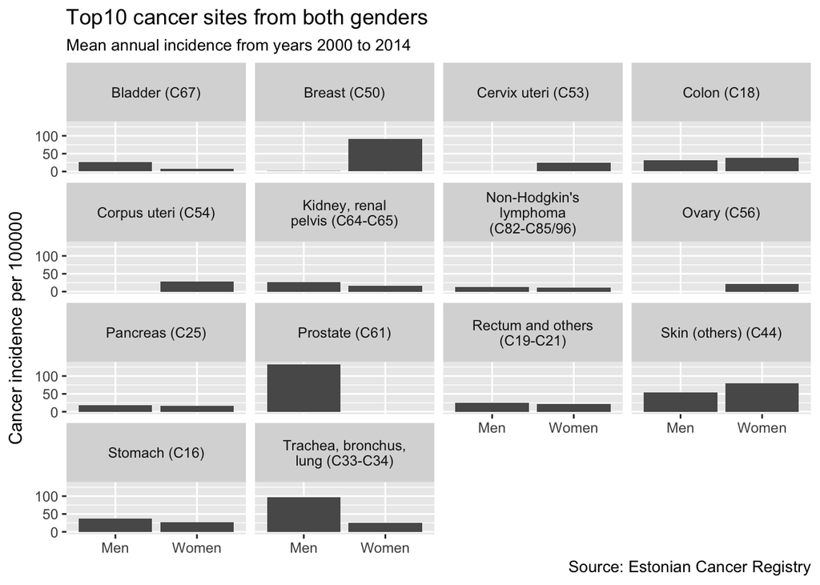

```r
incidence_sex_filt %>%
  filter(Site %in% listof_top10$Site) %>%
  ggplot(aes(Sex, incidence)) +
  geom_bar(stat = "identity") + ## use the values that we have in our table
  facet_wrap(~ Site, labeller = label_wrap_gen(width = 20)) +
  labs(title = "Top10 cancer sites from both genders",
       subtitle = "Mean annual incidence from years 2000 to 2014",
       y = "Cancer incidence per 100000",
       caption = paste("Source:", data_source)) +
  theme(axis.title.x = element_blank())
```

Here is another take using the same data:

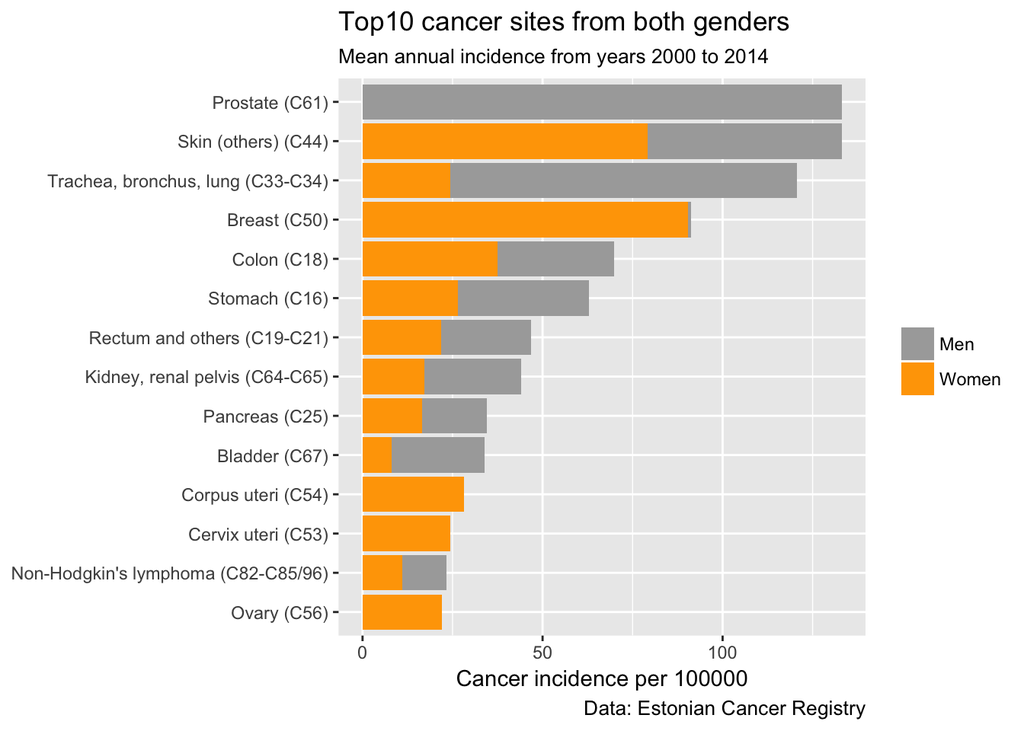

```r
incidence_sex_filt %>%
  filter(Site %in% listof_top10$Site) %>%
  ggplot(aes(reorder(Site, incidence), incidence, fill = Sex)) +
  geom_bar(stat = "identity") +
  labs(y = "Cancer incidence per 100000",
       title = "Top10 cancer sites from both genders",
       subtitle = "Mean annual incidence from years 2000 to 2014",
       caption = paste("Data:", data_source)) +
  coord_flip() +
  theme(axis.title.y = element_blank(),
        legend.title = element_blank()) +
  scale_fill_manual(values = c("darkgray", "orange"))
```

What these two graphs tell us?

## Age groups

First convert age groups to numerics:

```r
# str_extract(unique(incidence_long$age), "^[0-9]{1,2}") %>% parse_number()
# function(x) parse_number(str_extract(x, "^[0-9]{1,2}"))
incidence_long <- incidence_long %>%
  mutate_at("age", ~ parse_number(str_extract(.x, "^[0-9]{1,2}")))
incidence_long
```

```
## # A tibble: 39,420 x 6
##     Year                                                              Site
##    <dbl>                                                             <chr>
##  1  2000                                 All malignant neoplasms (C00-C97)
##  2  2000                                 All malignant neoplasms (C00-C97)
##  3  2000 All malignant neoplasms except skin (other) (C00-C97, except C44)
##  4  2000 All malignant neoplasms except skin (other) (C00-C97, except C44)
##  5  2000                            Lip, oral cavity and pharynx (C00-C14)
##  6  2000                            Lip, oral cavity and pharynx (C00-C14)
##  7  2000                                                         Lip (C00)
##  8  2000                                                         Lip (C00)
##  9  2000                                                   Tongue (C01-02)
## 10  2000                                                   Tongue (C01-02)
## # ... with 39,410 more rows, and 4 more variables: Sex <chr>, age <dbl>,
## #   cases <int>, ave_pop <int>
```

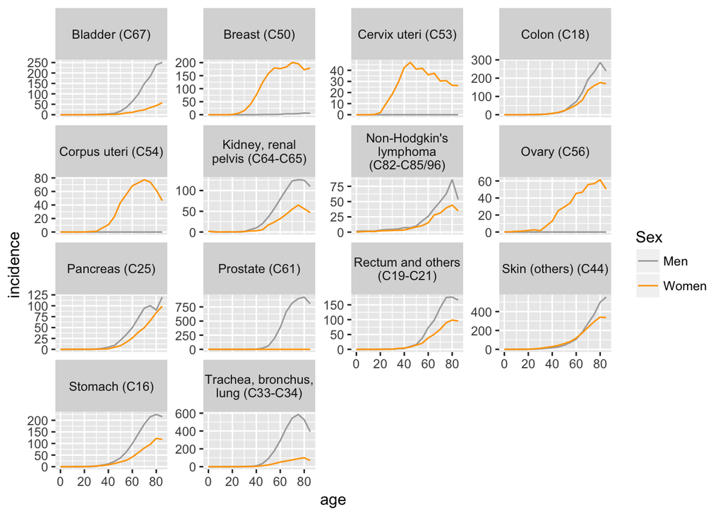

```r
p <- incidence_long %>%
  filter(Site %in% listof_top10$Site) %>%
  mutate(incidence = cases/(ave_pop/1E5)) %>%
  group_by(Sex, Site, age) %>%
  summarise(incidence = mean(incidence)) %>%
  ggplot(aes(age, incidence, color = Sex)) +
  geom_line() +
  facet_wrap(~ Site, labeller = label_wrap_gen(20), scales = "free_y") +
  scale_color_manual(values = c("darkgray", "orange"))
p
```

Cancer incidence increases with age: use log on x and y axis!

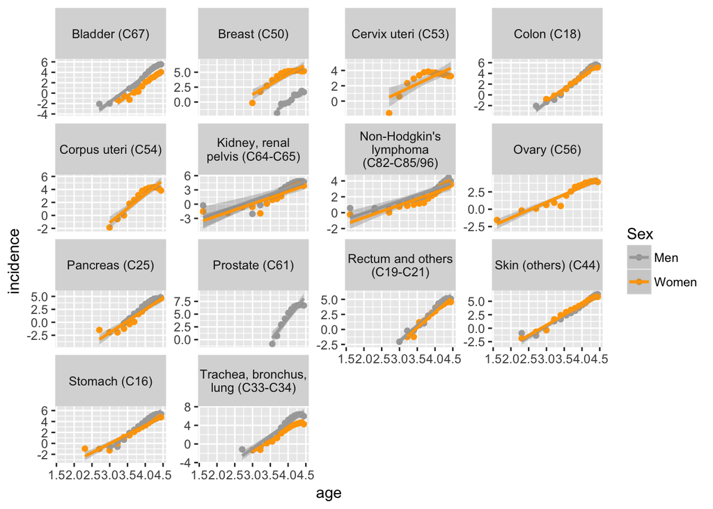

```r
incidence_long %>%
  filter(Site %in% listof_top10$Site) %>%
  mutate(incidence = cases / (ave_pop/1E5)) %>%
  group_by(Sex, Site, age) %>%
  summarise(incidence = mean(incidence)) %>%
  mutate_at(vars(age, incidence), log) %>%
  filter(is.finite(incidence), is.finite(age)) %>%
  ggplot(aes(age, incidence, color = Sex)) +
  geom_point() +
  facet_wrap(~ Site, labeller = label_wrap_gen(20), scales = "free_y") +
  scale_color_manual(values = c("darkgray", "orange")) +
  geom_smooth(method = "lm")
```

There are cancer that show linear relationship between age and incidence, like skin cancer and bladder cancer. And there are cancers that initially show increase but then reach plateau, these seem to be mostly gender specific cancers like breast cancer, cervical cancer, and endometrial cancer in women and prostate cancer in men. If you compare breast cancer in women and men, then it seems that they have different mechanism…

## Age weighted incidence

Size distribution of different age groups in estonian population

```r
## install.packages("viridis")
library(viridis)
```

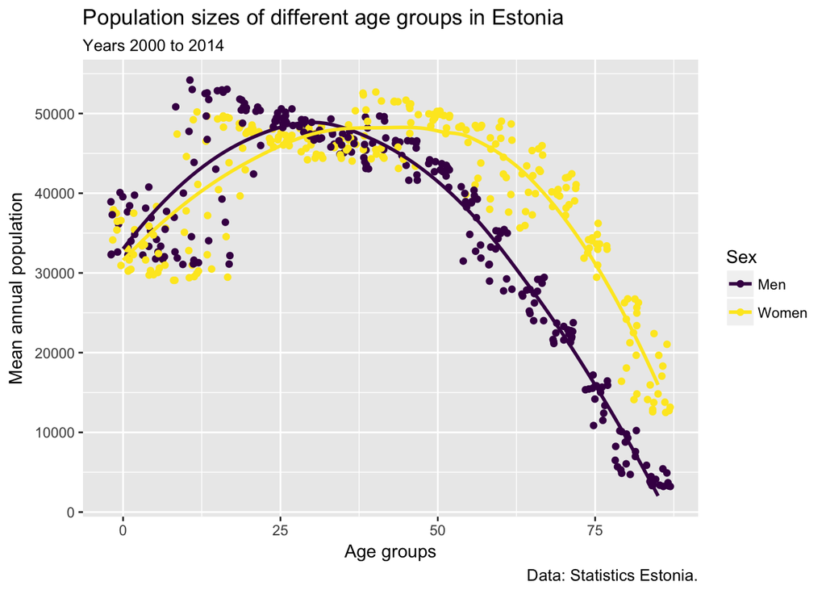

```r
## Plot age group differences
incidence_long %>%
  select(Year, age, Sex, ave_pop) %>%
  distinct() %>%
  ggplot(aes(age, ave_pop, color = Sex, group = Sex)) +
  geom_jitter(jitter = 0.1) +
  geom_smooth(method = "loess", se = FALSE) +
  labs(title = "Population sizes of different age groups in Estonia",
       subtitle = "Years 2000 to 2014",
       caption = "Data: Statistics Estonia.",
       y = "Mean annual population",
       x = "Age groups") +
  scale_color_viridis(discrete = TRUE)
```

Let’s calculate age group size weighted incidence values.

```r
## raw incidence
raw_incidence <- incidence_long %>%
  mutate(incidence = (cases / ave_pop) * 100000) %>% ## incidence
  group_by(Year, Site, Sex) %>% ## calculate mean population size and mean incidence
  summarise(incidence = mean(incidence),
            ave_pop = sum(ave_pop)) %>%
  group_by(Site, Sex) %>%
  summarise(incidence = mean(incidence),
            ave_pop = mean(ave_pop))

## Age weighted incidence
age_weighted_incidence <- incidence_long %>%
  mutate(incidence = (cases / ave_pop) * 100000) %>% ## incidence
  group_by(Site, Sex, age) %>% ## calculate mean population size and mean incidence
  summarise(incidence = mean(incidence),
            ave_pop = mean(ave_pop)) %>%
  mutate(wt = ave_pop / sum(ave_pop),
         incidence = wt * incidence) %>%
  summarise(incidence = sum(incidence),
            ave_pop = sum(ave_pop))
```

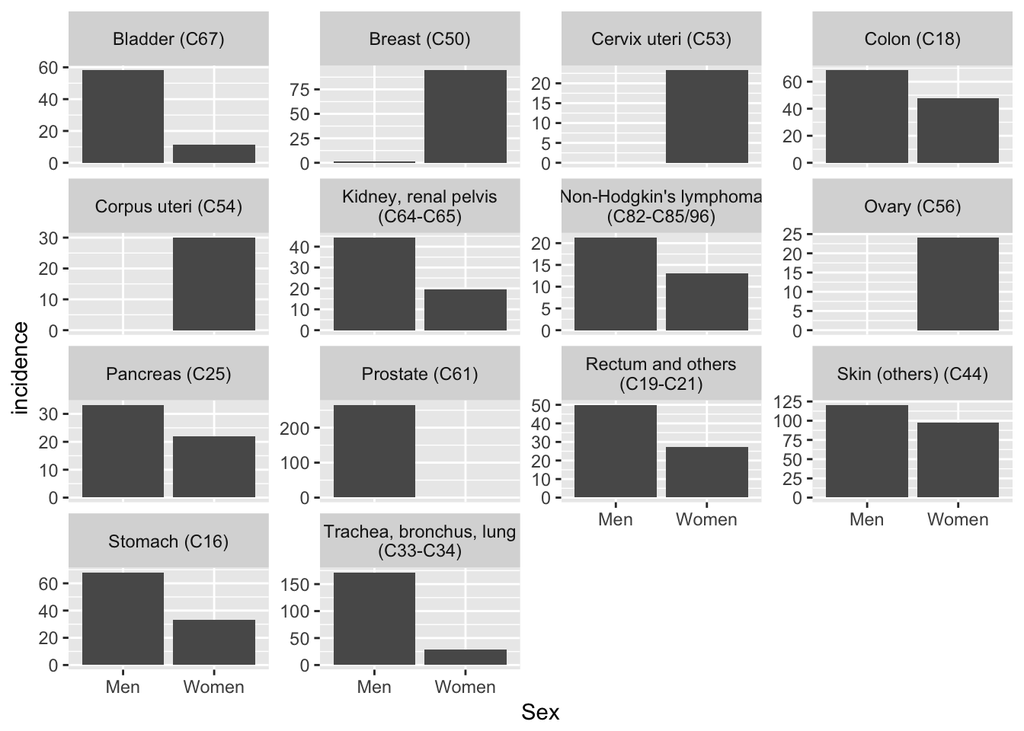

```r
## plot age group weighted incidence values
p <- raw_incidence %>%
  filter(Site %in% listof_top10$Site) %>%
  ggplot(aes(Sex, incidence)) +
  geom_bar(stat = "identity") +
  facet_wrap(~ Site, labeller = label_wrap_gen(), scales = "free_y") +
  scale_color_viridis(discrete = T)
p
```

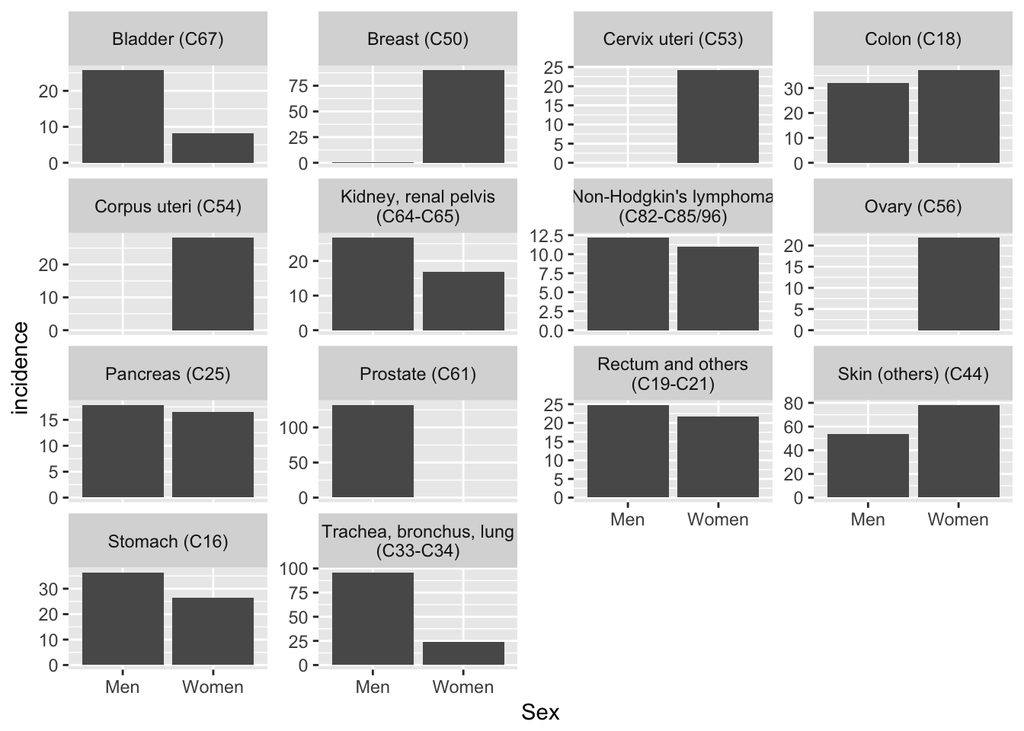

```r
p %+% filter(age_weighted_incidence, Site %in% listof_top10$Site)
```

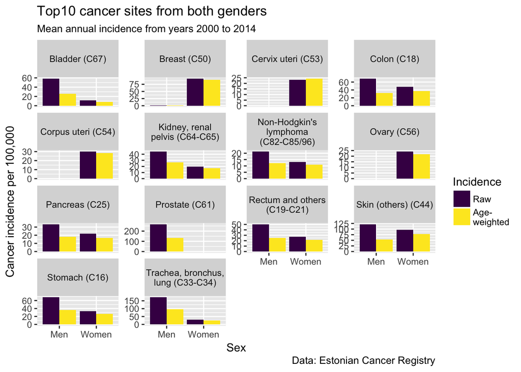

```r
bind_rows(list(raw_incidence, age_weighted_incidence), .id = "type") %>%
  filter(Site %in% listof_top10$Site) %>%
  ggplot(aes(Sex, incidence, fill = type)) +
  geom_bar(stat = "identity", position = "dodge") +
  facet_wrap(~ Site, labeller = label_wrap_gen(20), scales = "free_y") +
  scale_fill_viridis(discrete = TRUE, labels = c("Raw", "Age-\nweighted"), "Incidence") +
  labs(y = "Cancer incidence per 100,000",
       title = "Top10 cancer sites from both genders",
       subtitle = "Mean annual incidence from years 2000 to 2014",
       caption = paste("Data:", data_source))
```